# BIOS 611 Project 1

Justin DeMonte

09/24/2018

# 1)

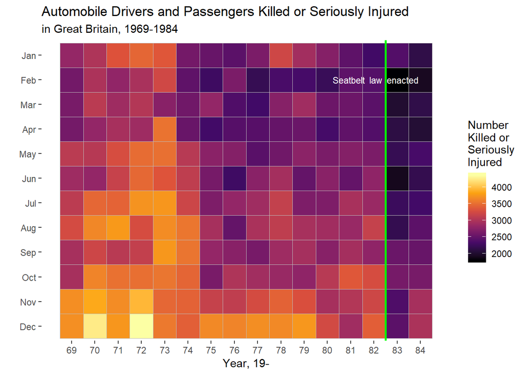

This graphic was created from the “seatbelts” dataset in R. This data set describes the monthly number of drivers and passengers killed or seriously injured in automobile accidents in Great Britain between January 1969 and December 1984, inclusive.

I was interested in exploring potential trends in automobile injuries/deaths by season, as well as potential trends across decades.

Seasonal trends may be related to poor winter driving conditions. Weather data, and more detailed accident data could be used to explore the validity of this explanation. The seatbelt law appears to have been effective in reducing deaths and injuries.

Reference: Harvey, A. C. and Durbin, J. (1986). The effects of seat belt legislation on British road casualties: A case study in structural time series modelling. Journal of the Royal Statistical Society series A, 149, 187-227. doi: 10.2307/2981553.

# 2)

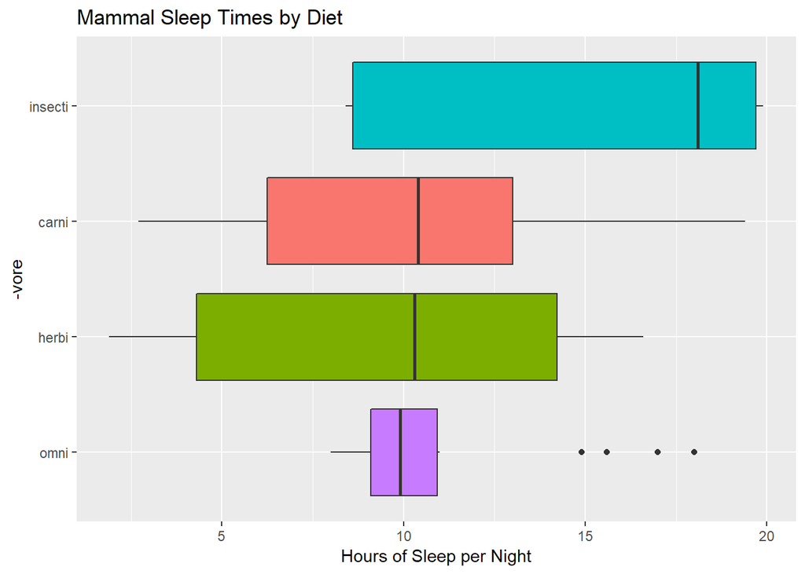

The graph is based on the “msleep” data set in R, which comes from a study on mammalian sleep paterns. Measurements (e.g. nightly sleep times) were taken by V.M. Savage and G.B. West, and diet categories (herbivore, carnivore, etc.) were added from wikipedia. Cases with missing values for diet were removed from the dataset when the graph was created.

I was interested in exploring a potential relationship between mammals’ diets and nightly sleep times. The graph shows the distributions of mammals’ nightly sleep times, by diet category. Median nightly sleep times were consistent across diet categories (roughly 10 hours/night), with the exception of insectivore. However, it should be noted that there were only 5 observations for insectivores in the data set (there were 19, 32, 20 observations for carni, herbi, and omni -vores respectively).

In short, this graphical exploration did not illuminate a clear relationship between diet and sleep times. More data and additional analyses would be helpful in further exploring this hypothesis.

Reference: V. M. Savage and G. B. West. A quantitative, theoretical framework for understanding mammalian sleep. Proceedings of the National Academy of Sciences, 104 (3):1051-1056, 2007. #3)

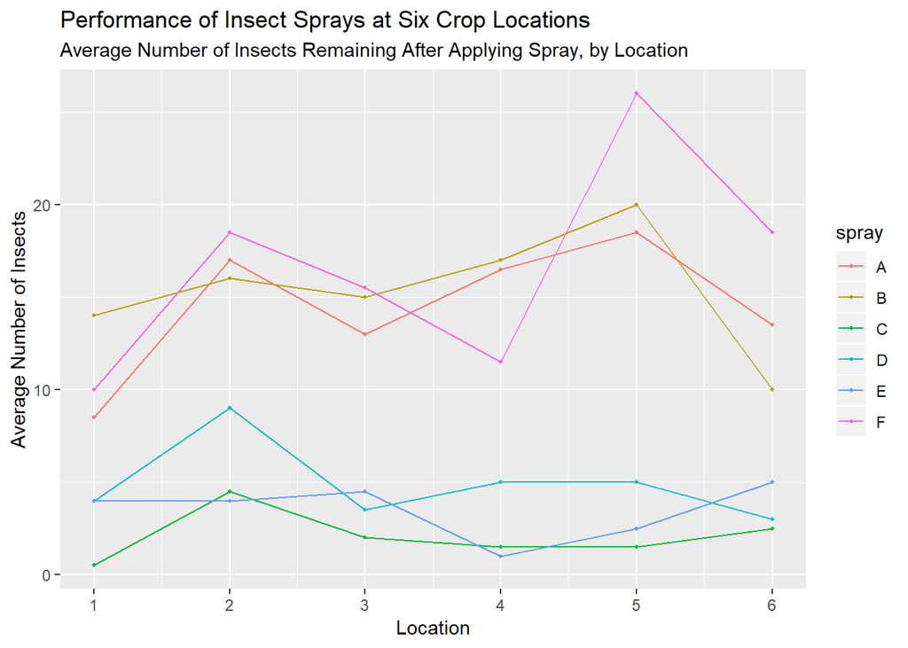

This figure is derived from the “InsectSprays” data set in R, which comes from a 1942 experiment by Beall. Beall applied six different insect sprays to crops across six locations in Chatham, Ontario.

Each spray was tested twice at each location (on two different crop plots within the location). For each test, the number of insects left in the crop plot after spraying was recorded. Points on the graph represent the average of two insect counts for each spray at each location (note that lower insect counts indicate a more effective spray).

The goal of this graphical exploration was to explore the performance of the sprays and to assess possible differences in spray performances by location.

While there is some variation in the overall number of insects by location, the relative performance of the sprays was roughly consistent across locations. Spray C had the best performance overall, with a sum total (over all locations) of only 25 insects remaining after treatment. Spray F had the worst performance overall, with a sum (over all locations) of 200 insects remaining after treatment. The big takeaway is the separation of the sprays into two distinct groups: Sprays C, D, and E were generally more effective than sprays A, B, and F.

Reference: Beall, G., (1942) The Transformation of data from entomological field experiments,Biometrika, 29, 243-262.

# 4)

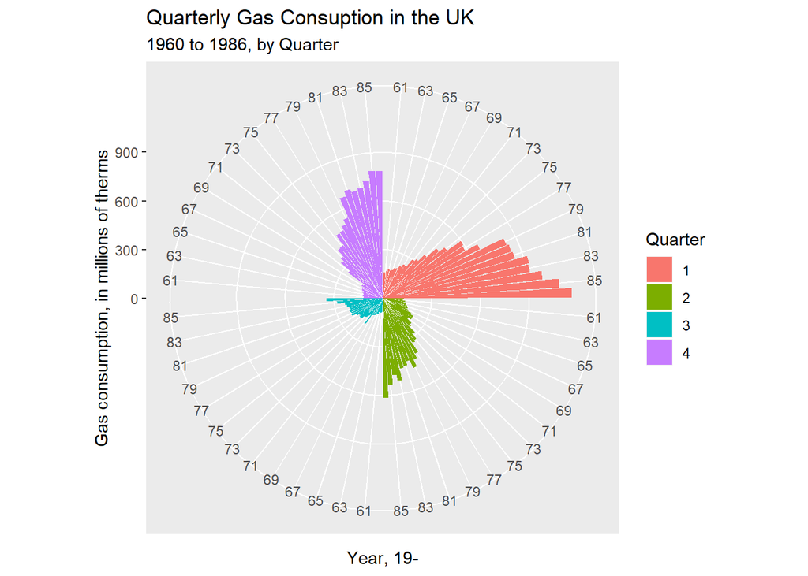

This graph is based on the R data set “UKgas”. This data set describes quarterly gas consumption in the UK, measured in millions of therms, for the years 1960 through 1986, inclusive.

I aimed to explore seasonal trends in gas usage, as well as trends over the decades.

The graph shows a clear trend in gas consumption by quarter. The most gas is consumed during quarter 1, followed by quarters 4, 2, and 3, in that order. This trend is most likely driven by winter weather.

The graph shows also shows a steady increase in gas consumption between 1960 and 1986. While overall consumption incresed, the quarterly trend described above held over time.

Refererence: Durbin, J. and Koopman, S. J. (2001) Time Series Analysis by State Space Methods. Oxford University Press. http://www.ssfpack.com/dkbook/